# Modelos multinivel

Hector Najera

14/05/2026

# Introducción

Esta nota brinda una introducción bastante elemental a los siguientes tipos de modelos:

- Modelación no multinivel
- Modelación multinivel: Ordenadas al origen
- Modelación multinivel: Ordenadas al origen y pendientes

También se aborda el cómputo de los estadísticos de validación cruzada: loo

```r
library(pacman)
p_load(haven, dplyr, brms, bayesplot, tidybayes, ggplot2)
color_scheme_set(scheme = "viridis")
```

```r
D<-read_dta("pobreza_18.dta")
```

# Modelo multinivel y no multinivel

## Modelo de un nivel

Vamos a utilizar datos de la ENIGH 2018. Usaremos el nivel educativo, el tamaño del hogar y el de localidad como variables de ajuste. Además ajustaremos el modelo por la entidad federativa de residencia.

```r
M<-brm(pobreza ~ 1 + factor(niv_edexpjh),
        prior = c(set_prior("normal(0,10)", class = "b")),
        family="bernoulli", chains=4, cores=4, iter=2000,  threads = threading(14, grainsize = 100),backend = "cmdstanr", data=D)
```

```
## Running MCMC with 4 parallel chains, with 14 thread(s) per chain...
##
## Chain 1 Iteration:    1 / 2000 [  0%]  (Warmup)
## Chain 2 Iteration:    1 / 2000 [  0%]  (Warmup)
## Chain 3 Iteration:    1 / 2000 [  0%]  (Warmup)
## Chain 4 Iteration:    1 / 2000 [  0%]  (Warmup)
## Chain 1 Iteration:  100 / 2000 [  5%]  (Warmup)
## Chain 2 Iteration:  100 / 2000 [  5%]  (Warmup)
## Chain 3 Iteration:  100 / 2000 [  5%]  (Warmup)
## Chain 4 Iteration:  100 / 2000 [  5%]  (Warmup)
## Chain 3 Iteration:  200 / 2000 [ 10%]  (Warmup)
## Chain 1 Iteration:  200 / 2000 [ 10%]  (Warmup)
## Chain 2 Iteration:  200 / 2000 [ 10%]  (Warmup)
## Chain 3 Iteration:  300 / 2000 [ 15%]  (Warmup)
## Chain 4 Iteration:  200 / 2000 [ 10%]  (Warmup)
## Chain 1 Iteration:  300 / 2000 [ 15%]  (Warmup)
## Chain 2 Iteration:  300 / 2000 [ 15%]  (Warmup)
## Chain 3 Iteration:  400 / 2000 [ 20%]  (Warmup)
## Chain 4 Iteration:  300 / 2000 [ 15%]  (Warmup)
## Chain 1 Iteration:  400 / 2000 [ 20%]  (Warmup)
## Chain 2 Iteration:  400 / 2000 [ 20%]  (Warmup)
## Chain 3 Iteration:  500 / 2000 [ 25%]  (Warmup)
## Chain 4 Iteration:  400 / 2000 [ 20%]  (Warmup)
## Chain 1 Iteration:  500 / 2000 [ 25%]  (Warmup)
## Chain 3 Iteration:  600 / 2000 [ 30%]  (Warmup)
## Chain 4 Iteration:  500 / 2000 [ 25%]  (Warmup)
## Chain 1 Iteration:  600 / 2000 [ 30%]  (Warmup)
## Chain 2 Iteration:  500 / 2000 [ 25%]  (Warmup)
## Chain 3 Iteration:  700 / 2000 [ 35%]  (Warmup)
## Chain 2 Iteration:  600 / 2000 [ 30%]  (Warmup)
## Chain 3 Iteration:  800 / 2000 [ 40%]  (Warmup)
## Chain 4 Iteration:  600 / 2000 [ 30%]  (Warmup)
## Chain 1 Iteration:  700 / 2000 [ 35%]  (Warmup)
## Chain 2 Iteration:  700 / 2000 [ 35%]  (Warmup)
## Chain 3 Iteration:  900 / 2000 [ 45%]  (Warmup)
## Chain 4 Iteration:  700 / 2000 [ 35%]  (Warmup)
## Chain 1 Iteration:  800 / 2000 [ 40%]  (Warmup)
## Chain 2 Iteration:  800 / 2000 [ 40%]  (Warmup)
## Chain 3 Iteration: 1000 / 2000 [ 50%]  (Warmup)
## Chain 3 Iteration: 1001 / 2000 [ 50%]  (Sampling)
```

[output cut: 44 more lines]

[output not shown]

```r
summary(M)
```

```
##  Family: bernoulli
##   Links: mu = logit
## Formula: pobreza ~ 1 + factor(niv_edexpjh)
##    Data: D (Number of observations: 10000)
##   Draws: 4 chains, each with iter = 2000; warmup = 1000; thin = 1;
##          total post-warmup draws = 4000
##
## Regression Coefficients:
##                    Estimate Est.Error l-95% CI u-95% CI Rhat Bulk_ESS Tail_ESS
## Intercept              0.26      0.04     0.18     0.34 1.00     2439     2693
## factorniv_edexpjh1    -0.74      0.06    -0.85    -0.61 1.00     3058     2885
## factorniv_edexpjh2    -0.92      0.06    -1.03    -0.81 1.00     2707     3138
## factorniv_edexpjh3    -1.56      0.08    -1.71    -1.41 1.00     3264     2628
## factorniv_edexpjh4    -2.90      0.13    -3.16    -2.65 1.00     3218     2873
##
## Draws were sampled using sample(hmc). For each parameter, Bulk_ESS
## and Tail_ESS are effective sample size measures, and Rhat is the potential
## scale reduction factor on split chains (at convergence, Rhat = 1).
```

```r
M1<-brm(pobreza ~ 1 + factor(niv_edexpjh) + tamhogesc + factor(tam_loc) + factor(ent),
        prior = c(set_prior("normal(0,10)", class = "b")),
        family="bernoulli", chains=4, cores=4, iter=2000,  threads = threading(14, grainsize = 100),backend = "cmdstanr", data=D)
```

```
## Running MCMC with 4 parallel chains, with 14 thread(s) per chain...
##
## Chain 1 Iteration:    1 / 2000 [  0%]  (Warmup)
## Chain 2 Iteration:    1 / 2000 [  0%]  (Warmup)
## Chain 3 Iteration:    1 / 2000 [  0%]  (Warmup)
## Chain 4 Iteration:    1 / 2000 [  0%]  (Warmup)
## Chain 1 Iteration:  100 / 2000 [  5%]  (Warmup)
## Chain 2 Iteration:  100 / 2000 [  5%]  (Warmup)
## Chain 4 Iteration:  100 / 2000 [  5%]  (Warmup)
## Chain 3 Iteration:  100 / 2000 [  5%]  (Warmup)
## Chain 1 Iteration:  200 / 2000 [ 10%]  (Warmup)
## Chain 4 Iteration:  200 / 2000 [ 10%]  (Warmup)
## Chain 2 Iteration:  200 / 2000 [ 10%]  (Warmup)
## Chain 3 Iteration:  200 / 2000 [ 10%]  (Warmup)
## Chain 1 Iteration:  300 / 2000 [ 15%]  (Warmup)
## Chain 4 Iteration:  300 / 2000 [ 15%]  (Warmup)
## Chain 2 Iteration:  300 / 2000 [ 15%]  (Warmup)
## Chain 3 Iteration:  300 / 2000 [ 15%]  (Warmup)
## Chain 4 Iteration:  400 / 2000 [ 20%]  (Warmup)
## Chain 1 Iteration:  400 / 2000 [ 20%]  (Warmup)
## Chain 3 Iteration:  400 / 2000 [ 20%]  (Warmup)
## Chain 2 Iteration:  400 / 2000 [ 20%]  (Warmup)
## Chain 4 Iteration:  500 / 2000 [ 25%]  (Warmup)
## Chain 1 Iteration:  500 / 2000 [ 25%]  (Warmup)
## Chain 3 Iteration:  500 / 2000 [ 25%]  (Warmup)
## Chain 2 Iteration:  500 / 2000 [ 25%]  (Warmup)
## Chain 4 Iteration:  600 / 2000 [ 30%]  (Warmup)
## Chain 1 Iteration:  600 / 2000 [ 30%]  (Warmup)
## Chain 3 Iteration:  600 / 2000 [ 30%]  (Warmup)
## Chain 2 Iteration:  600 / 2000 [ 30%]  (Warmup)
## Chain 4 Iteration:  700 / 2000 [ 35%]  (Warmup)
## Chain 1 Iteration:  700 / 2000 [ 35%]  (Warmup)
## Chain 3 Iteration:  700 / 2000 [ 35%]  (Warmup)
## Chain 4 Iteration:  800 / 2000 [ 40%]  (Warmup)
## Chain 2 Iteration:  700 / 2000 [ 35%]  (Warmup)
## Chain 1 Iteration:  800 / 2000 [ 40%]  (Warmup)
## Chain 3 Iteration:  800 / 2000 [ 40%]  (Warmup)
## Chain 4 Iteration:  900 / 2000 [ 45%]  (Warmup)
## Chain 2 Iteration:  800 / 2000 [ 40%]  (Warmup)
## Chain 1 Iteration:  900 / 2000 [ 45%]  (Warmup)
```

[output cut: 43 more lines]

```
## Chain 1 Iteration: 2000 / 2000 [100%]  (Sampling)
## Chain 2 Iteration: 1800 / 2000 [ 90%]  (Sampling)
## Chain 4 Iteration: 1900 / 2000 [ 95%]  (Sampling)
## Chain 1 finished in 6.1 seconds.
## Chain 3 Iteration: 2000 / 2000 [100%]  (Sampling)
## Chain 3 finished in 6.2 seconds.
## Chain 2 Iteration: 1900 / 2000 [ 95%]  (Sampling)
## Chain 4 Iteration: 2000 / 2000 [100%]  (Sampling)
## Chain 4 finished in 6.3 seconds.
## Chain 2 Iteration: 2000 / 2000 [100%]  (Sampling)
## Chain 2 finished in 6.5 seconds.
##
## All 4 chains finished successfully.
## Mean chain execution time: 6.3 seconds.
## Total execution time: 6.6 seconds.
```

```r
summary(M1)
```

```
##  Family: bernoulli
##   Links: mu = logit
## Formula: pobreza ~ 1 + factor(niv_edexpjh) + tamhogesc + factor(tam_loc) + factor(ent)
##    Data: D (Number of observations: 10000)
##   Draws: 4 chains, each with iter = 2000; warmup = 1000; thin = 1;
##          total post-warmup draws = 4000
##
## Regression Coefficients:
##                    Estimate Est.Error l-95% CI u-95% CI Rhat Bulk_ESS Tail_ESS
## Intercept             -1.61      0.17    -1.93    -1.29 1.01      252      664
## factorniv_edexpjh1    -0.76      0.07    -0.90    -0.64 1.00     1985     2708
## factorniv_edexpjh2    -0.88      0.06    -1.00    -0.77 1.00     1904     2896
## factorniv_edexpjh3    -1.48      0.08    -1.65    -1.32 1.00     1865     2893
## factorniv_edexpjh4    -2.78      0.13    -3.05    -2.53 1.00     2564     2762
## tamhogesc              0.24      0.02     0.21     0.27 1.00     3395     3109
## factortam_loc2         0.36      0.08     0.20     0.51 1.00     2054     2456
## factortam_loc3         0.70      0.08     0.55     0.86 1.00     2026     2540
## factortam_loc4         0.25      0.06     0.13     0.37 1.00     1937     2792
## factorent2             0.03      0.19    -0.35     0.40 1.01      304      748
## factorent3            -0.05      0.21    -0.47     0.35 1.01      375     1030
## factorent4             1.18      0.20     0.77     1.59 1.01      335      660
## factorent5             0.11      0.20    -0.28     0.49 1.01      333      929
## factorent6             0.26      0.19    -0.11     0.64 1.01      326      634
## factorent7             2.01      0.22     1.59     2.44 1.01      398      912
## factorent8             0.57      0.18     0.21     0.92 1.01      291      753
## factorent9             0.51      0.21     0.10     0.91 1.00      418     1001
## factorent10            0.61      0.20     0.21     1.00 1.01      358      902
## factorent11            1.02      0.19     0.65     1.39 1.01      324      705
## factorent12            1.73      0.21     1.31     2.14 1.01      382     1075
## factorent13            0.94      0.20     0.54     1.33 1.01      314      865
## factorent14            0.19      0.21    -0.22     0.59 1.01      341      945
## factorent15            1.12      0.19     0.74     1.49 1.01      294      746
## factorent16            0.68      0.20     0.28     1.07 1.01      339     1002
## factorent17            1.32      0.20     0.93     1.71 1.01      331     1049
## factorent18            0.53      0.22     0.09     0.98 1.01      417     1196
## factorent19           -0.25      0.20    -0.65     0.16 1.01      356      967
## factorent20            1.92      0.20     1.53     2.31 1.01      350      994
## factorent21            1.37      0.21     0.96     1.78 1.01      354      691
## factorent22            0.34      0.19    -0.03     0.71 1.01      314      698
## factorent23            0.65      0.22     0.22     1.06 1.01      375     1282
## factorent24            1.20      0.19     0.82     1.58 1.01      324      892
## factorent25            0.62      0.19     0.24     0.99 1.01      318      848
## factorent26            0.56      0.20     0.16     0.94 1.01      350      948
## factorent27            1.42      0.20     1.01     1.81 1.01      336      970
## factorent28            1.07      0.21     0.67     1.47 1.01      356      814
## factorent29            1.15      0.21     0.74     1.55 1.01      365      832
## factorent30            1.85      0.19     1.46     2.24 1.01      318      974
## factorent31            0.80      0.19     0.44     1.16 1.01      313      770
## factorent32            1.02      0.20     0.63     1.42 1.01      338      780
##
## Draws were sampled using sample(hmc). For each parameter, Bulk_ESS
## and Tail_ESS are effective sample size measures, and Rhat is the potential
## scale reduction factor on split chains (at convergence, Rhat = 1).
```

¿Incrementa Chiapas el riesgo de vivir en pobreza, relativo a Aguascalientes?

```r
get_variables(M1)
```

```
##  [1] "b_Intercept"          "b_factorniv_edexpjh1" "b_factorniv_edexpjh2"
##  [4] "b_factorniv_edexpjh3" "b_factorniv_edexpjh4" "b_tamhogesc"
##  [7] "b_factortam_loc2"     "b_factortam_loc3"     "b_factortam_loc4"
## [10] "b_factorent2"         "b_factorent3"         "b_factorent4"
## [13] "b_factorent5"         "b_factorent6"         "b_factorent7"
## [16] "b_factorent8"         "b_factorent9"         "b_factorent10"
## [19] "b_factorent11"        "b_factorent12"        "b_factorent13"
## [22] "b_factorent14"        "b_factorent15"        "b_factorent16"
## [25] "b_factorent17"        "b_factorent18"        "b_factorent19"
## [28] "b_factorent20"        "b_factorent21"        "b_factorent22"
## [31] "b_factorent23"        "b_factorent24"        "b_factorent25"
## [34] "b_factorent26"        "b_factorent27"        "b_factorent28"
## [37] "b_factorent29"        "b_factorent30"        "b_factorent31"
## [40] "b_factorent32"        "Intercept"            "lprior"
## [43] "lp__"                 "accept_stat__"        "treedepth__"
## [46] "stepsize__"           "divergent__"          "n_leapfrog__"
## [49] "energy__"
```

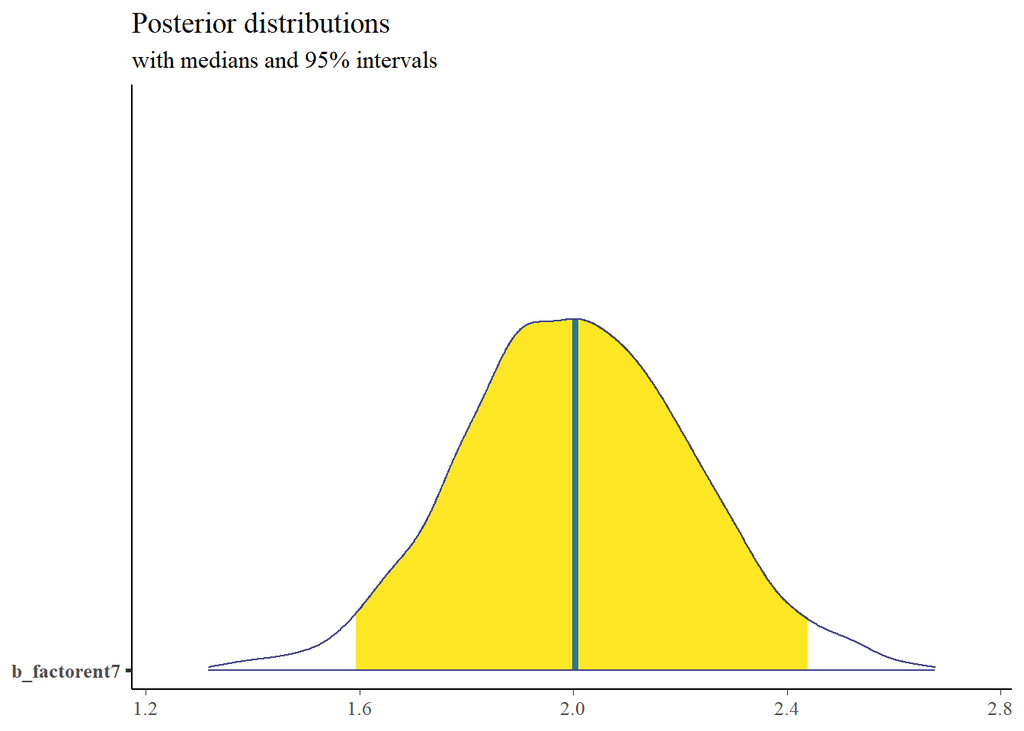

```r
plot_title <- ggtitle("Posterior distributions",
                      "with medians and 95% intervals")
mcmc_areas(M1,
           pars = c( "b_factorent7"),
           prob = 0.95) + plot_title
```

## Chequeos predictivos posteriores

Quisieramos saber si el modelo hace buenas predicciones de las proporciones población pobre y no pobre. Para ello podemos utilizar la función `pp_check`. Dado que se trata de una variable categórica vamos a solicitar una gráfica de barras.

Como puede apreciarse, el modelo hace un muy buen trabjo en predecir las proporciones de población pobre y no pobre.

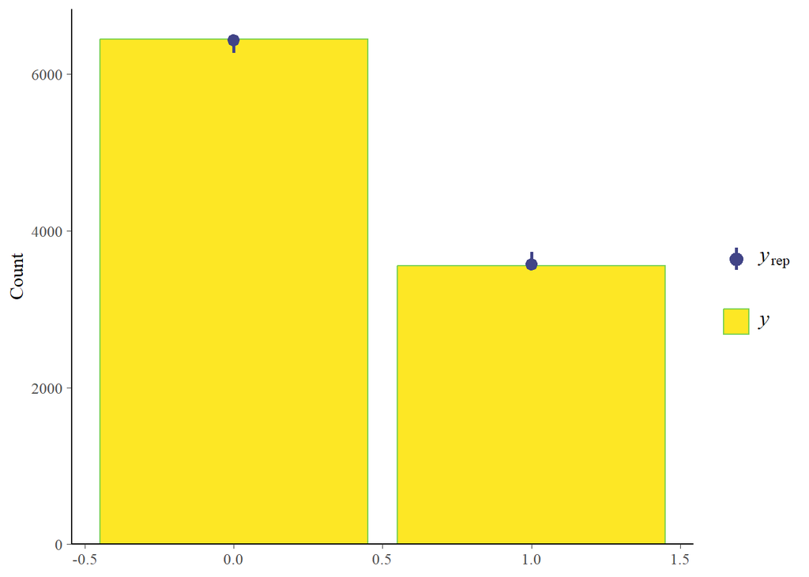

```r
pp_check(M1, ndraws = 11, type = "bars")
```

## Compración de modelos: Validacion cruzada.

NOTA: El comando `loo` toma mucho tiempo. Modera tus expectativas. Abajo utilizamos una aproximación con `loo_subsample`.

*The Pareto k estimate is a diagnostic for Pareto smoothed importance sampling (PSIS), which is used to compute components of elpd_loo. In importance-sampling LOO (the full posterior distribution is used as the proposal distribution). The Pareto k diagnostic estimates how far an individual leave-one-out distribution is from the full distribution. If leaving out an observation changes the posterior too much then importance sampling is not able to give reliable estimate. If k<0.5, then the corresponding component of elpd_loo is estimated with high accuracy. If 0.5<k<0.7 the accuracy is lower, but still ok. If k>0.7, then importance sampling is not able to provide useful estimate for that component/observation. Pareto k is also useful as a measure of influence of an observation. Highly influential observations have high k values. **Very high k values often indicate model misspecification, outliers or mistakes in data processing.***

```r
M.loo<-loo(M)
M1.loo<-loo(M1)
M.loo
```

```
##
## Computed from 4000 by 10000 log-likelihood matrix.
##
##          Estimate   SE
## elpd_loo  -5957.0 39.0
## p_loo         5.0  0.1
## looic     11914.0 77.9
## ------
## MCSE of elpd_loo is 0.0.
## MCSE and ESS estimates assume MCMC draws (r_eff in [0.6, 1.3]).
##
## All Pareto k estimates are good (k < 0.7).
## See help('pareto-k-diagnostic') for details.
```

```r
M1.loo
```

```
##
## Computed from 4000 by 10000 log-likelihood matrix.
##
##          Estimate   SE
## elpd_loo  -5444.8 47.4
## p_loo        40.1  0.5
## looic     10889.5 94.7
## ------
## MCSE of elpd_loo is 0.1.
## MCSE and ESS estimates assume MCMC draws (r_eff in [0.1, 2.2]).
##
## All Pareto k estimates are good (k < 0.7).
## See help('pareto-k-diagnostic') for details.
```

*When using loo_compare(), the returned matrix will have one row per model and several columns of estimates. The values in the elpd_diff and se_diff columns of the returned matrix are computed by making pairwise comparisons between each model and the model with the largest ELPD (the model in the first row). For this reason the elpd_diff column will always have the value 0 in the first row (i.e., the difference between the preferred model and itself) and negative values in subsequent rows for the remaining models.*

El modelo con el valor más bajo “elpd_diff” es el peor

```r
loo_compare(M1.loo,M.loo)
```

```
##    elpd_diff se_diff
## M1    0.0       0.0
## M  -512.2      31.9
```

### LOO eficiente basado en n=400: loo_subsample

```r
fastloo<-loo_subsample(M)
fastloo1<-loo_subsample(M1)
loo_compare(fastloo1,fastloo)
```

```
##    elpd_diff se_diff subsampling_se_diff
## M1   0.0       0.0     0.0
## M  512.0      61.3     1.6
```

Gráficas con loo

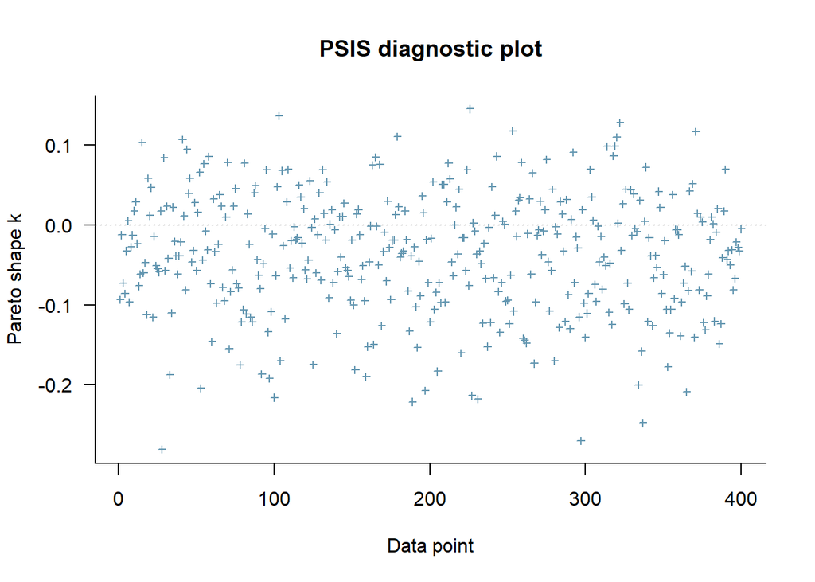

```r
plot(fastloo1)
```

## Multinivel

En `brms` la especificación de efectos aleatorios se hace como en el paquete `lmer`:

- Ordenadas al origen: (1|UNIDAD DEL EFECTO ALEATORIO).
- Pendientes: (1 + pendiente | UNIDAD DEL EFECTO ALEATORIO)

Comenzaremos por añadir efector aleatorios considerando las ordenadas al origen entre estados. El *híperprior* `set_prior("normal(0,5)", class = "sd")` especifica la varianza de las ordenadas al origen de `ent`.

Si se quisieran ordenadas al origen de entidades especificas es necesario hacer la especificación en Stan: `alpha[3] ~ normal(2.0, 0.2)`

```r
M1.b<-brm(pobreza ~ 1 + factor(niv_edexpjh) + tamhogesc + factor(tam_loc) + (1 | ent),
        prior = c(set_prior("normal(0,10)", class = "b"),
                  set_prior("normal(0,5)", class = "sd")),
        family="bernoulli", chains=4, cores=14, iter=1500,  threads = threading(14, grainsize = 100),backend = "cmdstanr", data=D)
```

```
## Running MCMC with 4 chains, at most 14 in parallel, with 14 thread(s) per chain...
##
## Chain 1 Iteration:    1 / 1500 [  0%]  (Warmup)
## Chain 2 Iteration:    1 / 1500 [  0%]  (Warmup)
## Chain 3 Iteration:    1 / 1500 [  0%]  (Warmup)
## Chain 4 Iteration:    1 / 1500 [  0%]  (Warmup)
## Chain 2 Iteration:  100 / 1500 [  6%]  (Warmup)
## Chain 1 Iteration:  100 / 1500 [  6%]  (Warmup)
## Chain 3 Iteration:  100 / 1500 [  6%]  (Warmup)
## Chain 4 Iteration:  100 / 1500 [  6%]  (Warmup)
## Chain 2 Iteration:  200 / 1500 [ 13%]  (Warmup)
## Chain 1 Iteration:  200 / 1500 [ 13%]  (Warmup)
## Chain 3 Iteration:  200 / 1500 [ 13%]  (Warmup)
## Chain 4 Iteration:  200 / 1500 [ 13%]  (Warmup)
## Chain 2 Iteration:  300 / 1500 [ 20%]  (Warmup)
## Chain 1 Iteration:  300 / 1500 [ 20%]  (Warmup)
## Chain 3 Iteration:  300 / 1500 [ 20%]  (Warmup)
## Chain 2 Iteration:  400 / 1500 [ 26%]  (Warmup)
## Chain 4 Iteration:  300 / 1500 [ 20%]  (Warmup)
## Chain 1 Iteration:  400 / 1500 [ 26%]  (Warmup)
## Chain 3 Iteration:  400 / 1500 [ 26%]  (Warmup)
## Chain 2 Iteration:  500 / 1500 [ 33%]  (Warmup)
## Chain 4 Iteration:  400 / 1500 [ 26%]  (Warmup)
## Chain 1 Iteration:  500 / 1500 [ 33%]  (Warmup)
## Chain 3 Iteration:  500 / 1500 [ 33%]  (Warmup)
## Chain 2 Iteration:  600 / 1500 [ 40%]  (Warmup)
## Chain 4 Iteration:  500 / 1500 [ 33%]  (Warmup)
## Chain 1 Iteration:  600 / 1500 [ 40%]  (Warmup)
## Chain 2 Iteration:  700 / 1500 [ 46%]  (Warmup)
## Chain 3 Iteration:  600 / 1500 [ 40%]  (Warmup)
## Chain 1 Iteration:  700 / 1500 [ 46%]  (Warmup)
## Chain 2 Iteration:  751 / 1500 [ 50%]  (Sampling)
## Chain 3 Iteration:  700 / 1500 [ 46%]  (Warmup)
## Chain 4 Iteration:  600 / 1500 [ 40%]  (Warmup)
## Chain 1 Iteration:  751 / 1500 [ 50%]  (Sampling)
## Chain 3 Iteration:  751 / 1500 [ 50%]  (Sampling)
## Chain 2 Iteration:  850 / 1500 [ 56%]  (Sampling)
## Chain 4 Iteration:  700 / 1500 [ 46%]  (Warmup)
## Chain 4 Iteration:  751 / 1500 [ 50%]  (Sampling)
## Chain 1 Iteration:  850 / 1500 [ 56%]  (Sampling)
```

[output cut: 23 more lines]

```
## Chain 2 Iteration: 1500 / 1500 [100%]  (Sampling)
## Chain 2 finished in 11.2 seconds.
## Chain 1 Iteration: 1450 / 1500 [ 96%]  (Sampling)
## Chain 3 Iteration: 1450 / 1500 [ 96%]  (Sampling)
## Chain 1 Iteration: 1500 / 1500 [100%]  (Sampling)
## Chain 3 Iteration: 1500 / 1500 [100%]  (Sampling)
## Chain 4 Iteration: 1450 / 1500 [ 96%]  (Sampling)
## Chain 1 finished in 11.6 seconds.
## Chain 3 finished in 11.6 seconds.
## Chain 4 Iteration: 1500 / 1500 [100%]  (Sampling)
## Chain 4 finished in 11.8 seconds.
##
## All 4 chains finished successfully.
## Mean chain execution time: 11.5 seconds.
## Total execution time: 11.9 seconds.
```

```r
summary(M1.b)
```

```
##  Family: bernoulli
##   Links: mu = logit
## Formula: pobreza ~ 1 + factor(niv_edexpjh) + tamhogesc + factor(tam_loc) + (1 | ent)
##    Data: D (Number of observations: 10000)
##   Draws: 4 chains, each with iter = 1500; warmup = 750; thin = 1;
##          total post-warmup draws = 3000
##
## Multilevel Hyperparameters:
## ~ent (Number of levels: 32)
##               Estimate Est.Error l-95% CI u-95% CI Rhat Bulk_ESS Tail_ESS
## sd(Intercept)     0.61      0.08     0.46     0.79 1.00      387      807
##
## Regression Coefficients:
##                    Estimate Est.Error l-95% CI u-95% CI Rhat Bulk_ESS Tail_ESS
## Intercept             -0.78      0.14    -1.07    -0.52 1.01      238      581
## factorniv_edexpjh1    -0.76      0.07    -0.89    -0.63 1.00     2007     1810
## factorniv_edexpjh2    -0.88      0.06    -1.00    -0.76 1.00     1933     1923
## factorniv_edexpjh3    -1.48      0.08    -1.65    -1.32 1.00     2098     1987
## factorniv_edexpjh4    -2.78      0.13    -3.04    -2.52 1.00     2413     2498
## tamhogesc              0.24      0.02     0.21     0.27 1.00     3152     1725
## factortam_loc2         0.36      0.08     0.21     0.51 1.00     2231     2259
## factortam_loc3         0.71      0.08     0.56     0.86 1.00     2131     2139
## factortam_loc4         0.25      0.06     0.14     0.38 1.00     2174     1981
##
## Draws were sampled using sample(hmc). For each parameter, Bulk_ESS
## and Tail_ESS are effective sample size measures, and Rhat is the potential
## scale reduction factor on split chains (at convergence, Rhat = 1).
```

A continuación graficamos las distribuciones posteriores del efecto aleatorio para cada entidad. Tenemos que hacer varias manipulaciones de las MCMC para poder hacerlo. Observamos las diferencias en efecto para los diferentes estados.

```r
ranef(M1.b, groups="ent", probs = 0.5)
```

```
## $ent
## , , Intercept
##
##       Estimate Est.Error        Q50
## 1  -0.78578965 0.1929186 -0.7880035
## 2  -0.75795740 0.1629760 -0.7561835
## 3  -0.82480627 0.1834197 -0.8235285
## 4   0.33773504 0.1764042  0.3380180
## 5  -0.68255423 0.1706246 -0.6830625
## 6  -0.53207211 0.1661112 -0.5332915
## 7   1.11321311 0.1813003  1.1115250
## 8  -0.24867665 0.1535590 -0.2494450
## 9  -0.28521261 0.1863477 -0.2854755
## 10 -0.20638545 0.1679797 -0.2086180
## 11  0.18575197 0.1611334  0.1824440
```

[output cut: 21 more lines]

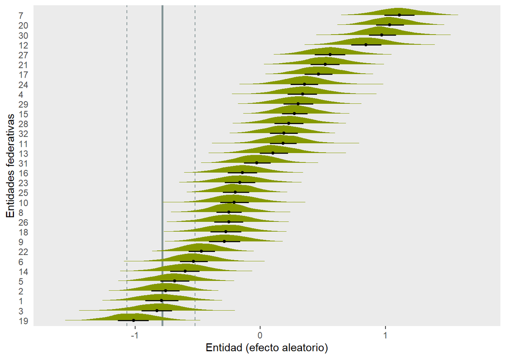

```r
library(stringr)

M1.b %>%
  spread_draws(r_ent[ent,]) %>%
  # add the grand mean to the group-specific deviations
  mutate(mu = r_ent) %>%
  ungroup() %>%
  mutate(ent = str_replace_all(ent, "[.]", " ")) %>%

  # plot
  ggplot(aes(x = mu, y = reorder(ent, mu))) +
  geom_vline(xintercept = fixef(M1.b)[1, 1], color = "#839496", size = 1) +
  geom_vline(xintercept = fixef(M1.b)[1, 3:4], color = "#839496", linetype = 2) +
  geom_halfeyeh(.width = .5, size = 2/3, fill = "#859900") +
  labs(x = expression("Entidad (efecto aleatorio)"),
       y = "Entidades federativas") +
  theme(panel.grid   = element_blank(),
        axis.ticks.y = element_blank(),
        axis.text.y  = element_text(hjust = 0),
        text = element_text(family = "Ubuntu"))
```

# Evaluación de modelos con cross-validation y loo

*The Pareto k estimate is a diagnostic for Pareto smoothed importance sampling (PSIS), which is used to compute components of elpd_loo. In importance-sampling LOO (the full posterior distribution is used as the proposal distribution). The Pareto k diagnostic estimates how far an individual leave-one-out distribution is from the full distribution. If leaving out an observation changes the posterior too much then importance sampling is not able to give reliable estimate. If k<0.5, then the corresponding component of elpd_loo is estimated with high accuracy. If 0.5<k<0.7 the accuracy is lower, but still ok. If k>0.7, then importance sampling is not able to provide useful estimate for that component/observation. Pareto k is also useful as a measure of influence of an observation. Highly influential observations have high k values. **Very high k values often indicate model misspecification, outliers or mistakes in data processing.***

```r
M1.b.loo<-loo(M1.b)
M1.b.loo
```

```
##
## Computed from 3000 by 10000 log-likelihood matrix.
##
##          Estimate   SE
## elpd_loo  -5444.6 46.7
## p_loo        39.1  0.5
## looic     10889.1 93.4
## ------
## MCSE of elpd_loo is 0.1.
## MCSE and ESS estimates assume MCMC draws (r_eff in [0.9, 2.4]).
##
## All Pareto k estimates are good (k < 0.7).
## See help('pareto-k-diagnostic') for details.
```

*When using loo_compare(), the returned matrix will have one row per model and several columns of estimates. The values in the elpd_diff and se_diff columns of the returned matrix are computed by making pairwise comparisons between each model and the model with the largest ELPD (the model in the first row). For this reason the elpd_diff column will always have the value 0 in the first row (i.e., the difference between the preferred model and itself) and negative values in subsequent rows for the remaining models.*

El modelo con el valor más bajo “elpd_diff” es el peor

El modelo de referencia “0” es el mejor. La diferencia es trivial entre ambos.

```r
loo_compare(M1.loo,M1.b.loo,M.loo)
```

```
##      elpd_diff se_diff
## M1.b    0.0       0.0
## M1     -0.2       1.3
## M    -512.4      30.9
```

## Pendientes aleatorias (al interior de cada estado)

Ahora quisieramos ver si el efecto de la educación varía entre estados. Para ello usaremos: `(1 + niv_edexpjh | ent)`

```r
M1.c<-brm(pobreza ~ 1 + factor(niv_edexpjh) + tamhogesc + factor(tam_loc) + (1 + niv_edexpjh | ent),
        prior = c(set_prior("normal(0,10)", class = "b"),
                  set_prior("normal(0,5)", class = "sd")),
        family="bernoulli", chains=2, cores=14, iter=1500,  threads = threading(14, grainsize = 100),backend = "cmdstanr", data=D)
```

```
## Running MCMC with 2 chains, at most 14 in parallel, with 14 thread(s) per chain...
##
## Chain 1 Iteration:    1 / 1500 [  0%]  (Warmup)
## Chain 2 Iteration:    1 / 1500 [  0%]  (Warmup)
## Chain 2 Iteration:  100 / 1500 [  6%]  (Warmup)
## Chain 2 Iteration:  200 / 1500 [ 13%]  (Warmup)
## Chain 1 Iteration:  100 / 1500 [  6%]  (Warmup)
## Chain 2 Iteration:  300 / 1500 [ 20%]  (Warmup)
## Chain 1 Iteration:  200 / 1500 [ 13%]  (Warmup)
## Chain 2 Iteration:  400 / 1500 [ 26%]  (Warmup)
## Chain 1 Iteration:  300 / 1500 [ 20%]  (Warmup)
## Chain 2 Iteration:  500 / 1500 [ 33%]  (Warmup)
## Chain 2 Iteration:  600 / 1500 [ 40%]  (Warmup)
## Chain 1 Iteration:  400 / 1500 [ 26%]  (Warmup)
## Chain 2 Iteration:  700 / 1500 [ 46%]  (Warmup)
## Chain 1 Iteration:  500 / 1500 [ 33%]  (Warmup)
## Chain 2 Iteration:  751 / 1500 [ 50%]  (Sampling)
## Chain 1 Iteration:  600 / 1500 [ 40%]  (Warmup)
## Chain 1 Iteration:  700 / 1500 [ 46%]  (Warmup)
## Chain 2 Iteration:  850 / 1500 [ 56%]  (Sampling)
## Chain 1 Iteration:  751 / 1500 [ 50%]  (Sampling)
## Chain 2 Iteration:  950 / 1500 [ 63%]  (Sampling)
## Chain 1 Iteration:  850 / 1500 [ 56%]  (Sampling)
## Chain 2 Iteration: 1050 / 1500 [ 70%]  (Sampling)
## Chain 1 Iteration:  950 / 1500 [ 63%]  (Sampling)
## Chain 2 Iteration: 1150 / 1500 [ 76%]  (Sampling)
## Chain 1 Iteration: 1050 / 1500 [ 70%]  (Sampling)
## Chain 1 Iteration: 1150 / 1500 [ 76%]  (Sampling)
## Chain 2 Iteration: 1250 / 1500 [ 83%]  (Sampling)
## Chain 1 Iteration: 1250 / 1500 [ 83%]  (Sampling)
## Chain 2 Iteration: 1350 / 1500 [ 90%]  (Sampling)
## Chain 1 Iteration: 1350 / 1500 [ 90%]  (Sampling)
## Chain 2 Iteration: 1450 / 1500 [ 96%]  (Sampling)
## Chain 2 Iteration: 1500 / 1500 [100%]  (Sampling)
## Chain 2 finished in 21.8 seconds.
## Chain 1 Iteration: 1450 / 1500 [ 96%]  (Sampling)
## Chain 1 Iteration: 1500 / 1500 [100%]  (Sampling)
## Chain 1 finished in 22.4 seconds.
##
## Both chains finished successfully.
## Mean chain execution time: 22.1 seconds.
## Total execution time: 22.5 seconds.
```

```r
summary(M1.c)
```

```
##  Family: bernoulli
##   Links: mu = logit
## Formula: pobreza ~ 1 + factor(niv_edexpjh) + tamhogesc + factor(tam_loc) + (1 + niv_edexpjh | ent)
##    Data: D (Number of observations: 10000)
##   Draws: 2 chains, each with iter = 1500; warmup = 750; thin = 1;
##          total post-warmup draws = 1500
##
## Multilevel Hyperparameters:
## ~ent (Number of levels: 32)
##                            Estimate Est.Error l-95% CI u-95% CI Rhat Bulk_ESS
## sd(Intercept)                  0.67      0.10     0.51     0.90 1.01      433
## sd(niv_edexpjh)                0.06      0.03     0.00     0.12 1.00      378
## cor(Intercept,niv_edexpjh)    -0.63      0.34    -0.99     0.39 1.00      869
##                            Tail_ESS
## sd(Intercept)                   672
## sd(niv_edexpjh)                 330
## cor(Intercept,niv_edexpjh)      544
##
## Regression Coefficients:
##                    Estimate Est.Error l-95% CI u-95% CI Rhat Bulk_ESS Tail_ESS
## Intercept             -0.80      0.15    -1.11    -0.51 1.01      263      447
## factorniv_edexpjh1    -0.76      0.07    -0.89    -0.62 1.00     1654     1265
## factorniv_edexpjh2    -0.88      0.07    -1.01    -0.75 1.00      958      810
## factorniv_edexpjh3    -1.47      0.09    -1.66    -1.29 1.00      913     1152
## factorniv_edexpjh4    -2.75      0.14    -3.03    -2.48 1.01     1423     1224
## tamhogesc              0.24      0.02     0.21     0.27 1.00     2141     1050
## factortam_loc2         0.37      0.08     0.22     0.52 1.00     1453     1093
## factortam_loc3         0.72      0.08     0.56     0.87 1.00     1623     1195
## factortam_loc4         0.26      0.06     0.14     0.38 1.00     1726     1064
##
## Draws were sampled using sample(hmc). For each parameter, Bulk_ESS
## and Tail_ESS are effective sample size measures, and Rhat is the potential
## scale reduction factor on split chains (at convergence, Rhat = 1).
```

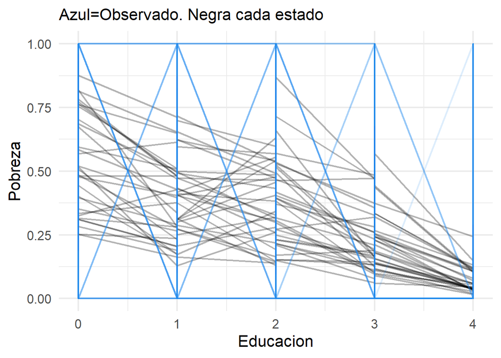

```r
M1.c$data %>%
  bind_cols(as_tibble(fitted(M1.c))) %>%
  ggplot() +
  geom_line(aes(x = niv_edexpjh, y = Estimate, group = ent), size = .75, alpha = .30) +
  geom_line(aes(x = niv_edexpjh, y = pobreza, group = ent), size = .75, alpha = .15, color = "dodgerblue2") +
  labs(x = "Educacion",
       y = "Pobreza",
       subtitle = "Azul=Observado. Negra cada estado") +
  theme_minimal(base_size = 16) +
  theme(plot.title = element_text(hjust = .5))
```

```r
M1.c.loo<-loo_subsample(M1.c)
loo_compare(M1.b.loo, M1.c.loo)
```

```
##      elpd_diff se_diff subsampling_se_diff
## M1.b 0.0       0.0     0.0
## M1.c 1.2       1.9     2.9
```

## Modelo de dos tres niveles

```r
M1.d<-brm(pobreza ~ 1 + factor(niv_edexpjh) + tamhogesc + factor(tam_loc) + (1 | ent / mun),
        prior = c(set_prior("normal(0,10)", class = "b"),
                  set_prior("normal(0,5)", class = "sd")),
        family="bernoulli", chains=2, cores=14, iter=1500,  threads = threading(14, grainsize = 100),backend = "cmdstanr", data=D)
```

```
## Running MCMC with 2 chains, at most 14 in parallel, with 14 thread(s) per chain...
##
## Chain 1 Iteration:    1 / 1500 [  0%]  (Warmup)
## Chain 2 Iteration:    1 / 1500 [  0%]  (Warmup)
## Chain 2 Iteration:  100 / 1500 [  6%]  (Warmup)
## Chain 2 Iteration:  200 / 1500 [ 13%]  (Warmup)
## Chain 1 Iteration:  100 / 1500 [  6%]  (Warmup)
## Chain 2 Iteration:  300 / 1500 [ 20%]  (Warmup)
## Chain 1 Iteration:  200 / 1500 [ 13%]  (Warmup)
## Chain 2 Iteration:  400 / 1500 [ 26%]  (Warmup)
## Chain 1 Iteration:  300 / 1500 [ 20%]  (Warmup)
## Chain 2 Iteration:  500 / 1500 [ 33%]  (Warmup)
## Chain 2 Iteration:  600 / 1500 [ 40%]  (Warmup)
## Chain 1 Iteration:  400 / 1500 [ 26%]  (Warmup)
## Chain 2 Iteration:  700 / 1500 [ 46%]  (Warmup)
## Chain 1 Iteration:  500 / 1500 [ 33%]  (Warmup)
## Chain 2 Iteration:  751 / 1500 [ 50%]  (Sampling)
## Chain 1 Iteration:  600 / 1500 [ 40%]  (Warmup)
## Chain 2 Iteration:  850 / 1500 [ 56%]  (Sampling)
## Chain 1 Iteration:  700 / 1500 [ 46%]  (Warmup)
## Chain 1 Iteration:  751 / 1500 [ 50%]  (Sampling)
## Chain 2 Iteration:  950 / 1500 [ 63%]  (Sampling)
## Chain 1 Iteration:  850 / 1500 [ 56%]  (Sampling)
## Chain 2 Iteration: 1050 / 1500 [ 70%]  (Sampling)
## Chain 1 Iteration:  950 / 1500 [ 63%]  (Sampling)
## Chain 2 Iteration: 1150 / 1500 [ 76%]  (Sampling)
## Chain 1 Iteration: 1050 / 1500 [ 70%]  (Sampling)
## Chain 2 Iteration: 1250 / 1500 [ 83%]  (Sampling)
## Chain 1 Iteration: 1150 / 1500 [ 76%]  (Sampling)
## Chain 2 Iteration: 1350 / 1500 [ 90%]  (Sampling)
## Chain 1 Iteration: 1250 / 1500 [ 83%]  (Sampling)
## Chain 2 Iteration: 1450 / 1500 [ 96%]  (Sampling)
## Chain 2 Iteration: 1500 / 1500 [100%]  (Sampling)
## Chain 2 finished in 32.2 seconds.
## Chain 1 Iteration: 1350 / 1500 [ 90%]  (Sampling)
## Chain 1 Iteration: 1450 / 1500 [ 96%]  (Sampling)
## Chain 1 Iteration: 1500 / 1500 [100%]  (Sampling)
## Chain 1 finished in 34.6 seconds.
##
## Both chains finished successfully.
## Mean chain execution time: 33.4 seconds.
## Total execution time: 34.7 seconds.
```

```r
summary(M1.d)
```

```
##  Family: bernoulli
##   Links: mu = logit
## Formula: pobreza ~ 1 + factor(niv_edexpjh) + tamhogesc + factor(tam_loc) + (1 | ent/mun)
##    Data: D (Number of observations: 10000)
##   Draws: 2 chains, each with iter = 1500; warmup = 750; thin = 1;
##          total post-warmup draws = 1500
##
## Multilevel Hyperparameters:
## ~ent (Number of levels: 32)
##               Estimate Est.Error l-95% CI u-95% CI Rhat Bulk_ESS Tail_ESS
## sd(Intercept)     0.64      0.09     0.48     0.84 1.01      412      808
##
## ~ent:mun (Number of levels: 958)
##               Estimate Est.Error l-95% CI u-95% CI Rhat Bulk_ESS Tail_ESS
## sd(Intercept)     0.46      0.05     0.37     0.56 1.00      600      980
##
## Regression Coefficients:
##                    Estimate Est.Error l-95% CI u-95% CI Rhat Bulk_ESS Tail_ESS
## Intercept             -0.70      0.15    -1.01    -0.41 1.00      505      753
## factorniv_edexpjh1    -0.78      0.07    -0.91    -0.65 1.00     2274     1147
## factorniv_edexpjh2    -0.88      0.06    -1.00    -0.76 1.01     2130      984
## factorniv_edexpjh3    -1.50      0.09    -1.67    -1.33 1.00     2579     1212
## factorniv_edexpjh4    -2.79      0.13    -3.05    -2.53 1.00     2985     1398
## tamhogesc              0.24      0.02     0.21     0.28 1.00     4095     1296
## factortam_loc2         0.27      0.10     0.08     0.46 1.00     1910     1096
## factortam_loc3         0.63      0.10     0.43     0.81 1.00     2149     1266
## factortam_loc4         0.16      0.08     0.02     0.31 1.00     1742     1238
##
## Draws were sampled using sample(hmc). For each parameter, Bulk_ESS
## and Tail_ESS are effective sample size measures, and Rhat is the potential
## scale reduction factor on split chains (at convergence, Rhat = 1).
```

```r
M1.d
```

```
##  Family: bernoulli
##   Links: mu = logit
## Formula: pobreza ~ 1 + factor(niv_edexpjh) + tamhogesc + factor(tam_loc) + (1 | ent/mun)
##    Data: D (Number of observations: 10000)
##   Draws: 2 chains, each with iter = 1500; warmup = 750; thin = 1;
##          total post-warmup draws = 1500
##
## Multilevel Hyperparameters:
## ~ent (Number of levels: 32)
##               Estimate Est.Error l-95% CI u-95% CI Rhat Bulk_ESS Tail_ESS
## sd(Intercept)     0.64      0.09     0.48     0.84 1.01      412      808
##
## ~ent:mun (Number of levels: 958)
##               Estimate Est.Error l-95% CI u-95% CI Rhat Bulk_ESS Tail_ESS
## sd(Intercept)     0.46      0.05     0.37     0.56 1.00      600      980
##
## Regression Coefficients:
##                    Estimate Est.Error l-95% CI u-95% CI Rhat Bulk_ESS Tail_ESS
## Intercept             -0.70      0.15    -1.01    -0.41 1.00      505      753
## factorniv_edexpjh1    -0.78      0.07    -0.91    -0.65 1.00     2274     1147
## factorniv_edexpjh2    -0.88      0.06    -1.00    -0.76 1.01     2130      984
## factorniv_edexpjh3    -1.50      0.09    -1.67    -1.33 1.00     2579     1212
## factorniv_edexpjh4    -2.79      0.13    -3.05    -2.53 1.00     2985     1398
## tamhogesc              0.24      0.02     0.21     0.28 1.00     4095     1296
## factortam_loc2         0.27      0.10     0.08     0.46 1.00     1910     1096
## factortam_loc3         0.63      0.10     0.43     0.81 1.00     2149     1266
## factortam_loc4         0.16      0.08     0.02     0.31 1.00     1742     1238
##
## Draws were sampled using sample(hmc). For each parameter, Bulk_ESS
## and Tail_ESS are effective sample size measures, and Rhat is the potential
## scale reduction factor on split chains (at convergence, Rhat = 1).
```

```r
M1.d.loo<-loo_subsample(M1.d)
loo_compare(M1.c.loo, M1.d.loo)
```

```
##      elpd_diff se_diff subsampling_se_diff
## M1.d  0.0       0.0     0.0
## M1.c 32.5      66.6    10.3
```

# Predicción

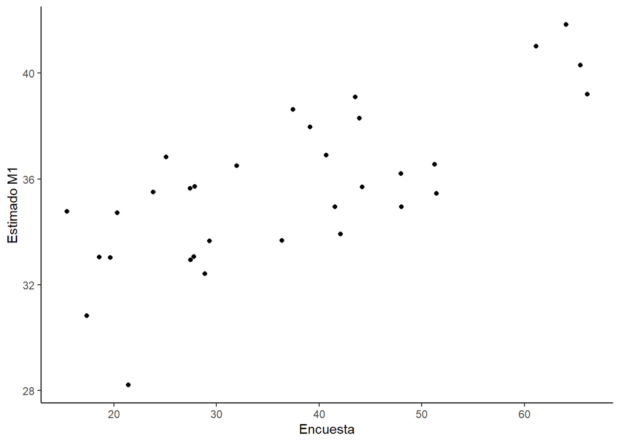

```r
D$prM1<-predict(M, newdata=D ,ndraws=300)
D$prM1.c<-predict(M1.c, newdata=D ,ndraws=300)

D %>% group_by(ent) %>% summarise(SPent=mean(pobreza, na.rm=T), M1Pent=mean(prM1[,1], na.rm=T),
                                  M1.cPent=mean(prM1.c[,1], na.rm=T)) -> Prent

ggplot(Prent, aes(SPent*100, M1Pent*100)) + geom_point() + theme_classic() + labs(y="Estimado M1", x="Encuesta")
```

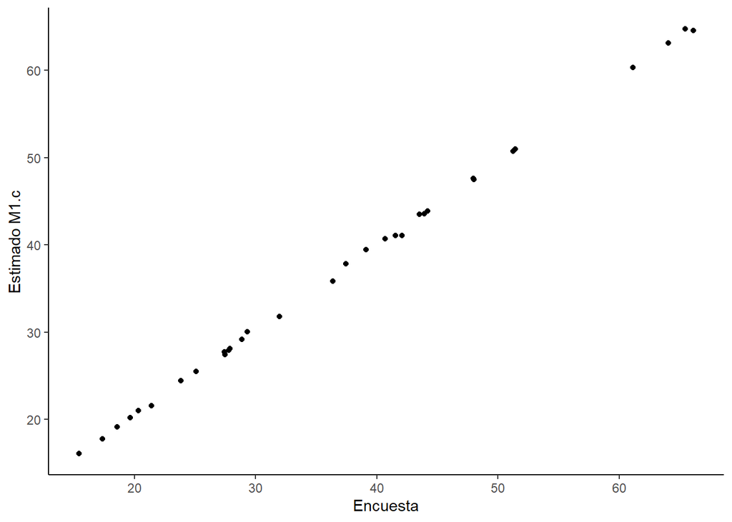

```r
ggplot(Prent, aes(SPent*100, M1.cPent*100)) + geom_point() + theme_classic() + labs(y="Estimado M1.c", x="Encuesta")
```

# Segundo ejemplo: Ordinal v multinomial

Cambiamos a `cumulative("logit")`

```r
D$i_privacion1<-D$i_privacion+1

M2<-brm(i_privacion1 ~ 1 + factor(niv_edexpjh) + tamhogesc + factor(tam_loc) + (1 | ent),
        prior = c(set_prior("normal(0,10)", class = "b"),
                  set_prior("normal(0,5)", class = "sd")),
        family=cumulative("logit", threshold="flexible"), chains=2, cores=14, iter=2000,  threads = threading(14, grainsize = 100),backend = "cmdstanr", data=D)
```

```
## Running MCMC with 2 chains, at most 14 in parallel, with 14 thread(s) per chain...
##
## Chain 1 Iteration:    1 / 2000 [  0%]  (Warmup)
## Chain 2 Iteration:    1 / 2000 [  0%]  (Warmup)
## Chain 2 Iteration:  100 / 2000 [  5%]  (Warmup)
## Chain 1 Iteration:  100 / 2000 [  5%]  (Warmup)
## Chain 1 Iteration:  200 / 2000 [ 10%]  (Warmup)
## Chain 2 Iteration:  200 / 2000 [ 10%]  (Warmup)
## Chain 1 Iteration:  300 / 2000 [ 15%]  (Warmup)
## Chain 2 Iteration:  300 / 2000 [ 15%]  (Warmup)
## Chain 1 Iteration:  400 / 2000 [ 20%]  (Warmup)
## Chain 2 Iteration:  400 / 2000 [ 20%]  (Warmup)
## Chain 1 Iteration:  500 / 2000 [ 25%]  (Warmup)
## Chain 2 Iteration:  500 / 2000 [ 25%]  (Warmup)
## Chain 1 Iteration:  600 / 2000 [ 30%]  (Warmup)
## Chain 2 Iteration:  600 / 2000 [ 30%]  (Warmup)
## Chain 1 Iteration:  700 / 2000 [ 35%]  (Warmup)
## Chain 1 Iteration:  800 / 2000 [ 40%]  (Warmup)
## Chain 2 Iteration:  700 / 2000 [ 35%]  (Warmup)
## Chain 1 Iteration:  900 / 2000 [ 45%]  (Warmup)
## Chain 2 Iteration:  800 / 2000 [ 40%]  (Warmup)
## Chain 1 Iteration: 1000 / 2000 [ 50%]  (Warmup)
## Chain 2 Iteration:  900 / 2000 [ 45%]  (Warmup)
## Chain 1 Iteration: 1001 / 2000 [ 50%]  (Sampling)
## Chain 1 Iteration: 1100 / 2000 [ 55%]  (Sampling)
## Chain 2 Iteration: 1000 / 2000 [ 50%]  (Warmup)
## Chain 2 Iteration: 1001 / 2000 [ 50%]  (Sampling)
## Chain 1 Iteration: 1200 / 2000 [ 60%]  (Sampling)
## Chain 2 Iteration: 1100 / 2000 [ 55%]  (Sampling)
## Chain 1 Iteration: 1300 / 2000 [ 65%]  (Sampling)
## Chain 2 Iteration: 1200 / 2000 [ 60%]  (Sampling)
## Chain 1 Iteration: 1400 / 2000 [ 70%]  (Sampling)
## Chain 2 Iteration: 1300 / 2000 [ 65%]  (Sampling)
## Chain 1 Iteration: 1500 / 2000 [ 75%]  (Sampling)
## Chain 2 Iteration: 1400 / 2000 [ 70%]  (Sampling)
## Chain 1 Iteration: 1600 / 2000 [ 80%]  (Sampling)
## Chain 2 Iteration: 1500 / 2000 [ 75%]  (Sampling)
## Chain 1 Iteration: 1700 / 2000 [ 85%]  (Sampling)
## Chain 2 Iteration: 1600 / 2000 [ 80%]  (Sampling)
## Chain 1 Iteration: 1800 / 2000 [ 90%]  (Sampling)
## Chain 2 Iteration: 1700 / 2000 [ 85%]  (Sampling)
## Chain 1 Iteration: 1900 / 2000 [ 95%]  (Sampling)
## Chain 2 Iteration: 1800 / 2000 [ 90%]  (Sampling)
## Chain 1 Iteration: 2000 / 2000 [100%]  (Sampling)
## Chain 1 finished in 38.6 seconds.
## Chain 2 Iteration: 1900 / 2000 [ 95%]  (Sampling)
## Chain 2 Iteration: 2000 / 2000 [100%]  (Sampling)
## Chain 2 finished in 40.4 seconds.
##
## Both chains finished successfully.
## Mean chain execution time: 39.5 seconds.
## Total execution time: 40.6 seconds.
```

```r
summary(M2)
```

```
##  Family: cumulative
##   Links: mu = logit; disc = identity
## Formula: i_privacion1 ~ 1 + factor(niv_edexpjh) + tamhogesc + factor(tam_loc) + (1 | ent)
##    Data: D (Number of observations: 10000)
##   Draws: 2 chains, each with iter = 2000; warmup = 1000; thin = 1;
##          total post-warmup draws = 2000
##
## Multilevel Hyperparameters:
## ~ent (Number of levels: 32)
##               Estimate Est.Error l-95% CI u-95% CI Rhat Bulk_ESS Tail_ESS
## sd(Intercept)     0.57      0.08     0.44     0.74 1.02      254      523
##
## Regression Coefficients:
##                    Estimate Est.Error l-95% CI u-95% CI Rhat Bulk_ESS Tail_ESS
## Intercept[1]          -1.91      0.12    -2.14    -1.68 1.00      189      286
## Intercept[2]          -0.30      0.12    -0.54    -0.08 1.00      190      281
## Intercept[3]           1.16      0.12     0.93     1.39 1.00      193      311
## Intercept[4]           2.59      0.12     2.34     2.83 1.00      204      331
## Intercept[5]           4.15      0.14     3.87     4.42 1.00      263      568
## Intercept[6]           6.36      0.24     5.92     6.85 1.00      546     1118
## factorniv_edexpjh1    -1.36      0.06    -1.47    -1.24 1.00      878     1033
## factorniv_edexpjh2    -1.71      0.05    -1.81    -1.60 1.00      848     1158
## factorniv_edexpjh3    -2.07      0.07    -2.20    -1.92 1.00      903     1174
## factorniv_edexpjh4    -2.79      0.08    -2.95    -2.63 1.00      788     1149
## tamhogesc              0.08      0.01     0.06     0.10 1.00     1447     1345
## factortam_loc2         0.28      0.06     0.16     0.40 1.00     1378     1381
## factortam_loc3         0.56      0.06     0.43     0.68 1.00     1097      965
## factortam_loc4         1.11      0.05     1.01     1.20 1.00     1003     1338
##
## Further Distributional Parameters:
##      Estimate Est.Error l-95% CI u-95% CI Rhat Bulk_ESS Tail_ESS
## disc     1.00      0.00     1.00     1.00   NA       NA       NA
##
## Draws were sampled using sample(hmc). For each parameter, Bulk_ESS
## and Tail_ESS are effective sample size measures, and Rhat is the potential
## scale reduction factor on split chains (at convergence, Rhat = 1).
```

En este caso `pp_check` lo hacemos con barras puesto que se trata de una variable de grupos

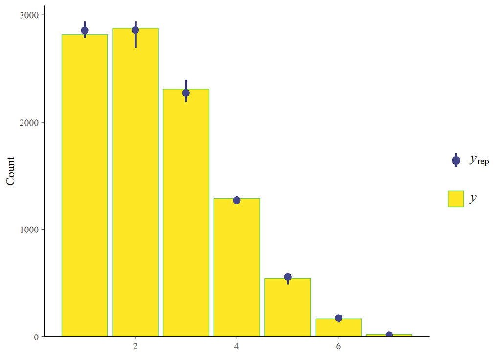

```r
pp_check(M2, nreps = 10, type = "bars")
```

# Multinomial

- Este modelo es sumamente pesado: predictores X categorías con efectos aleatorios X categorías.
- Este modelo necesita prior débiles para producir resultados razonables.
- Intenten estimar este modelo con ML.

```r
D$i_privacion1<-as.factor(D$i_privacion1)
#Ds<-sample_n(D,10000)

M3<-brm(i_privacion1 ~ 1  + factor(niv_edexpjh) + tamhogesc + factor(tam_loc) + (1 | ent),
         prior = c(set_prior("normal(0,5)", class="b", dpar = "mu2"),
                            set_prior("normal(0,5)", class="b", dpar = "mu3"),
                                set_prior("normal(0,5)", class="sd", dpar = "mu3"),
                                set_prior("normal(0,5)", class="sd", dpar = "mu2"),
                            set_prior("normal(0,5)", class="b", dpar = "mu4"),
                            set_prior("normal(0,5)", class="b", dpar = "mu5"),
                            set_prior("normal(0,5)", class="b", dpar = "mu6"),
                            set_prior("normal(0,5)", class="b", dpar = "mu7")),
        family = categorical(link = "logit"), chains=2, cores=2, iter=1500,  threads = threading(14, grainsize = 100),backend = "cmdstanr", data=D)
```

```
## Running MCMC with 2 parallel chains, with 14 thread(s) per chain...
##
## Chain 1 Iteration:    1 / 1500 [  0%]  (Warmup)
## Chain 2 Iteration:    1 / 1500 [  0%]  (Warmup)
## Chain 1 Iteration:  100 / 1500 [  6%]  (Warmup)
## Chain 2 Iteration:  100 / 1500 [  6%]  (Warmup)
## Chain 1 Iteration:  200 / 1500 [ 13%]  (Warmup)
## Chain 2 Iteration:  200 / 1500 [ 13%]  (Warmup)
## Chain 1 Iteration:  300 / 1500 [ 20%]  (Warmup)
## Chain 2 Iteration:  300 / 1500 [ 20%]  (Warmup)
## Chain 1 Iteration:  400 / 1500 [ 26%]  (Warmup)
## Chain 2 Iteration:  400 / 1500 [ 26%]  (Warmup)
## Chain 1 Iteration:  500 / 1500 [ 33%]  (Warmup)
## Chain 2 Iteration:  500 / 1500 [ 33%]  (Warmup)
## Chain 1 Iteration:  600 / 1500 [ 40%]  (Warmup)
## Chain 2 Iteration:  600 / 1500 [ 40%]  (Warmup)
## Chain 1 Iteration:  700 / 1500 [ 46%]  (Warmup)
## Chain 2 Iteration:  700 / 1500 [ 46%]  (Warmup)
## Chain 1 Iteration:  751 / 1500 [ 50%]  (Sampling)
## Chain 2 Iteration:  751 / 1500 [ 50%]  (Sampling)
## Chain 1 Iteration:  850 / 1500 [ 56%]  (Sampling)
## Chain 2 Iteration:  850 / 1500 [ 56%]  (Sampling)
## Chain 1 Iteration:  950 / 1500 [ 63%]  (Sampling)
## Chain 2 Iteration:  950 / 1500 [ 63%]  (Sampling)
## Chain 1 Iteration: 1050 / 1500 [ 70%]  (Sampling)
## Chain 2 Iteration: 1050 / 1500 [ 70%]  (Sampling)
## Chain 1 Iteration: 1150 / 1500 [ 76%]  (Sampling)
## Chain 2 Iteration: 1150 / 1500 [ 76%]  (Sampling)
## Chain 1 Iteration: 1250 / 1500 [ 83%]  (Sampling)
## Chain 2 Iteration: 1250 / 1500 [ 83%]  (Sampling)
## Chain 2 Iteration: 1350 / 1500 [ 90%]  (Sampling)
## Chain 1 Iteration: 1350 / 1500 [ 90%]  (Sampling)
## Chain 2 Iteration: 1450 / 1500 [ 96%]  (Sampling)
## Chain 1 Iteration: 1450 / 1500 [ 96%]  (Sampling)
## Chain 2 Iteration: 1500 / 1500 [100%]  (Sampling)
## Chain 2 finished in 103.7 seconds.
## Chain 1 Iteration: 1500 / 1500 [100%]  (Sampling)
## Chain 1 finished in 105.6 seconds.
##
## Both chains finished successfully.
## Mean chain execution time: 104.7 seconds.
## Total execution time: 105.7 seconds.
```

Claramente necesita más tiempo.

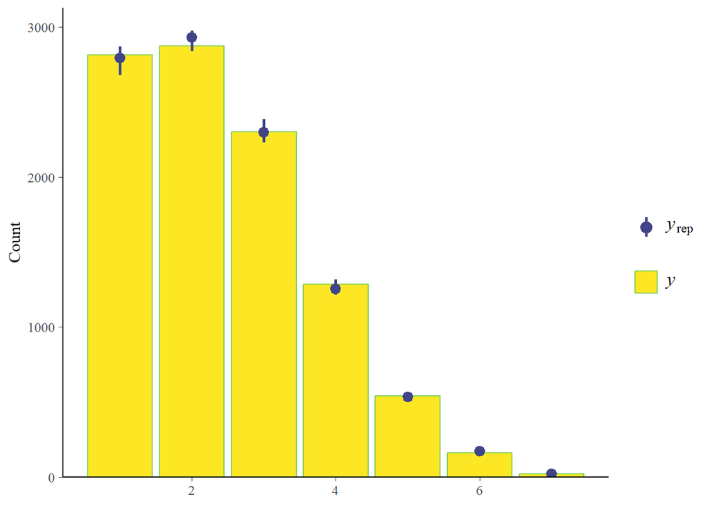

```r
pp_check(M3, nreps = 10, type = "bars")
```

¿Qué modelo es mejor el ordinal o el multinomial?

```r
M2.loo<-loo_subsample(M2)
M3.loo<-loo_subsample(M3)
M2.loo
```

```
##
## Computed from 2000 by 400 subsampled log-likelihood
## values from 10000 total observations.
##
##          Estimate    SE subsampling SE
## elpd_loo -13490.6  67.1            1.3
## p_loo        46.5   0.4            2.0
## looic     26981.2 134.1            2.6
## ------
## MCSE of elpd_loo is 0.0.
## MCSE and ESS estimates assume MCMC draws (r_eff in [0.6, 1.8]).
##
## All Pareto k estimates are good (k < 0.7).
## See help('pareto-k-diagnostic') for details.
```

```r
M3.loo
```

```
##
## Computed from 1500 by 400 subsampled log-likelihood
## values from 10000 total observations.
##
##          Estimate    SE subsampling SE
## elpd_loo -13251.3  65.8           19.7
## p_loo       199.9   6.2           30.2
## looic     26502.6 131.5           39.5
## ------
## MCSE of elpd_loo is 0.1.
## MCSE and ESS estimates assume MCMC draws (r_eff in [0.5, 1.9]).
##
## All Pareto k estimates are good (k < 0.69).
## See help('pareto-k-diagnostic') for details.
```